# Risk Factor Analysis

## Outcome Variable

**Outcome Variable:** y_rate_haz

## Predictor Variables

**Intervention Variable:** vagbrth

**Adjustment Set:**

unadjusted

## Stratifying Variables

The analysis was stratified on these variable(s):

- agecat
- studyid
- country

## Data Summary

| agecat | studyid | country | vagbrth | n_cell | n |
| --- | --- | --- | --- | --- | --- |
| 0-3 months | CMC-V-BCS-2002 | INDIA | 0 | 10 | 88 |
| 0-3 months | CMC-V-BCS-2002 | INDIA | 1 | 78 | 88 |
| 0-3 months | IRC | INDIA | 0 | 66 | 377 |
| 0-3 months | IRC | INDIA | 1 | 311 | 377 |
| 0-3 months | JiVitA-3 | BANGLADESH | 0 | 846 | 19843 |
| 0-3 months | JiVitA-3 | BANGLADESH | 1 | 18997 | 19843 |
| 0-3 months | JiVitA-4 | BANGLADESH | 0 | 100 | 1805 |
| 0-3 months | JiVitA-4 | BANGLADESH | 1 | 1705 | 1805 |
| 0-3 months | NIH-Crypto | BANGLADESH | 0 | 193 | 469 |
| 0-3 months | NIH-Crypto | BANGLADESH | 1 | 276 | 469 |
| 0-3 months | PROBIT | BELARUS | 0 | 1721 | 15323 |
| 0-3 months | PROBIT | BELARUS | 1 | 13602 | 15323 |
| 0-3 months | PROVIDE | BANGLADESH | 0 | 149 | 640 |
| 0-3 months | PROVIDE | BANGLADESH | 1 | 491 | 640 |
| 0-3 months | ZVITAMBO | ZIMBABWE | 0 | 690 | 7920 |
| 0-3 months | ZVITAMBO | ZIMBABWE | 1 | 7230 | 7920 |
| 3-6 months | CMC-V-BCS-2002 | INDIA | 0 | 21 | 307 |
| 3-6 months | CMC-V-BCS-2002 | INDIA | 1 | 286 | 307 |
| 3-6 months | IRC | INDIA | 0 | 67 | 397 |
| 3-6 months | IRC | INDIA | 1 | 330 | 397 |
| 3-6 months | JiVitA-3 | BANGLADESH | 0 | 769 | 12551 |
| 3-6 months | JiVitA-3 | BANGLADESH | 1 | 11782 | 12551 |
| 3-6 months | JiVitA-4 | BANGLADESH | 0 | 128 | 1762 |
| 3-6 months | JiVitA-4 | BANGLADESH | 1 | 1634 | 1762 |
| 3-6 months | NIH-Crypto | BANGLADESH | 0 | 182 | 443 |
| 3-6 months | NIH-Crypto | BANGLADESH | 1 | 261 | 443 |
| 3-6 months | PROBIT | BELARUS | 0 | 1473 | 13308 |
| 3-6 months | PROBIT | BELARUS | 1 | 11835 | 13308 |
| 3-6 months | PROVIDE | BANGLADESH | 0 | 138 | 598 |
| 3-6 months | PROVIDE | BANGLADESH | 1 | 460 | 598 |

[output cut: 94 more lines]

The following strata were considered:

- agecat: 0-3 months, studyid: CMC-V-BCS-2002, country: INDIA
- agecat: 0-3 months, studyid: IRC, country: INDIA
- agecat: 0-3 months, studyid: JiVitA-3, country: BANGLADESH
- agecat: 0-3 months, studyid: JiVitA-4, country: BANGLADESH
- agecat: 0-3 months, studyid: NIH-Crypto, country: BANGLADESH
- agecat: 0-3 months, studyid: PROBIT, country: BELARUS
- agecat: 0-3 months, studyid: PROVIDE, country: BANGLADESH
- agecat: 0-3 months, studyid: ZVITAMBO, country: ZIMBABWE
- agecat: 12-15 months, studyid: CMC-V-BCS-2002, country: INDIA
- agecat: 12-15 months, studyid: IRC, country: INDIA
- agecat: 12-15 months, studyid: JiVitA-4, country: BANGLADESH
- agecat: 12-15 months, studyid: NIH-Crypto, country: BANGLADESH
- agecat: 12-15 months, studyid: PROBIT, country: BELARUS
- agecat: 12-15 months, studyid: PROVIDE, country: BANGLADESH
- agecat: 12-15 months, studyid: TanzaniaChild2, country: TANZANIA, UNITED REPUBLIC OF
- agecat: 12-15 months, studyid: ZVITAMBO, country: ZIMBABWE
- agecat: 15-18 months, studyid: CMC-V-BCS-2002, country: INDIA
- agecat: 15-18 months, studyid: IRC, country: INDIA
- agecat: 15-18 months, studyid: JiVitA-4, country: BANGLADESH
- agecat: 15-18 months, studyid: NIH-Crypto, country: BANGLADESH
- agecat: 15-18 months, studyid: PROBIT, country: BELARUS
- agecat: 15-18 months, studyid: PROVIDE, country: BANGLADESH
- agecat: 15-18 months, studyid: TanzaniaChild2, country: TANZANIA, UNITED REPUBLIC OF
- agecat: 15-18 months, studyid: ZVITAMBO, country: ZIMBABWE
- agecat: 18-21 months, studyid: CMC-V-BCS-2002, country: INDIA
- agecat: 18-21 months, studyid: IRC, country: INDIA
- agecat: 18-21 months, studyid: NIH-Crypto, country: BANGLADESH
- agecat: 18-21 months, studyid: PROBIT, country: BELARUS
- agecat: 18-21 months, studyid: PROVIDE, country: BANGLADESH
- agecat: 18-21 months, studyid: TanzaniaChild2, country: TANZANIA, UNITED REPUBLIC OF
- agecat: 18-21 months, studyid: ZVITAMBO, country: ZIMBABWE
- agecat: 21-24 months, studyid: CMC-V-BCS-2002, country: INDIA
- agecat: 21-24 months, studyid: IRC, country: INDIA
- agecat: 21-24 months, studyid: NIH-Crypto, country: BANGLADESH
- agecat: 21-24 months, studyid: PROBIT, country: BELARUS
- agecat: 21-24 months, studyid: PROVIDE, country: BANGLADESH
- agecat: 21-24 months, studyid: ZVITAMBO, country: ZIMBABWE
- agecat: 3-6 months, studyid: CMC-V-BCS-2002, country: INDIA
- agecat: 3-6 months, studyid: IRC, country: INDIA
- agecat: 3-6 months, studyid: JiVitA-3, country: BANGLADESH
- agecat: 3-6 months, studyid: JiVitA-4, country: BANGLADESH
- agecat: 3-6 months, studyid: NIH-Crypto, country: BANGLADESH
- agecat: 3-6 months, studyid: PROBIT, country: BELARUS
- agecat: 3-6 months, studyid: PROVIDE, country: BANGLADESH
- agecat: 3-6 months, studyid: TanzaniaChild2, country: TANZANIA, UNITED REPUBLIC OF
- agecat: 3-6 months, studyid: ZVITAMBO, country: ZIMBABWE
- agecat: 6-9 months, studyid: CMC-V-BCS-2002, country: INDIA
- agecat: 6-9 months, studyid: IRC, country: INDIA
- agecat: 6-9 months, studyid: JiVitA-4, country: BANGLADESH
- agecat: 6-9 months, studyid: NIH-Crypto, country: BANGLADESH
- agecat: 6-9 months, studyid: PROBIT, country: BELARUS
- agecat: 6-9 months, studyid: PROVIDE, country: BANGLADESH
- agecat: 6-9 months, studyid: TanzaniaChild2, country: TANZANIA, UNITED REPUBLIC OF
- agecat: 6-9 months, studyid: ZVITAMBO, country: ZIMBABWE
- agecat: 9-12 months, studyid: CMC-V-BCS-2002, country: INDIA
- agecat: 9-12 months, studyid: IRC, country: INDIA
- agecat: 9-12 months, studyid: JiVitA-4, country: BANGLADESH
- agecat: 9-12 months, studyid: NIH-Crypto, country: BANGLADESH
- agecat: 9-12 months, studyid: PROBIT, country: BELARUS
- agecat: 9-12 months, studyid: PROVIDE, country: BANGLADESH
- agecat: 9-12 months, studyid: TanzaniaChild2, country: TANZANIA, UNITED REPUBLIC OF
- agecat: 9-12 months, studyid: ZVITAMBO, country: ZIMBABWE

### Dropped Strata

Some strata were dropped due to rare outcomes:

- agecat: 18-21 months, studyid: TanzaniaChild2, country: TANZANIA, UNITED REPUBLIC OF

## Methods Detail

We’re interested in the causal parameters $E[Y_a]$ for all values of $a \in \mathcal{A}$. These parameters represent the mean outcome if, possibly contrary to fact, we intervened to set all units to have $A=a$. Under the randomization and positivity assumptions, these are identified by the statistical parameters $\psi_a=E_W[E_{Y|A,W}(Y|A=a,W)]$. In addition, we’re interested in the mean of $Y$, $E[Y]$ under no intervention (the observed mean). We will estimate these parameters by using SuperLearner to fit the relevant likelihood factors – $E_{Y|A,W}(Y|A=a,W)$ and $p(A=a|W)$, and then updating our likelihood fit using a joint TMLE.

For unadjusted analyses ($W=\{\}$), initial likelihoods were estimated using Lrnr_glm to estimate the simple $E(Y|A)$ and Lrnr_mean to estimate $p(A)$. For adjusted analyses, a small library containing Lrnr_glmnet, Lrnr_xgboost, and Lrnr_mean was used.

Having estimated these parameters, we will then use the delta method to estimate relative risks and attributable risks relative to a prespecified baseline level of $A$.

# Results Detail

## Results Plots

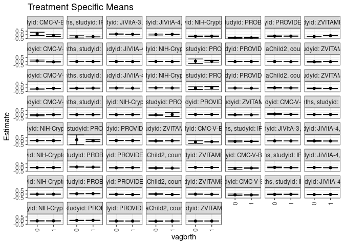

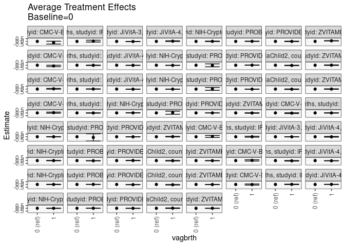

[figure not shown]

## Results Table

### Parameter: TSM

| agecat | studyid | country | intervention_level | baseline_level | estimate | ci_lower | ci_upper |
| --- | --- | --- | --- | --- | --- | --- | --- |
| 0-3 months | CMC-V-BCS-2002 | INDIA | 0 | NA | 0.1158390 | -0.1145272 | 0.3462052 |
| 0-3 months | CMC-V-BCS-2002 | INDIA | 1 | NA | -0.1139511 | -0.2284793 | 0.0005771 |
| 0-3 months | IRC | INDIA | 0 | NA | -0.2919819 | -0.4459867 | -0.1379771 |
| 0-3 months | IRC | INDIA | 1 | NA | -0.2481544 | -0.3066744 | -0.1896343 |
| 0-3 months | JiVitA-3 | BANGLADESH | 0 | NA | 0.0951188 | 0.0714463 | 0.1187914 |
| 0-3 months | JiVitA-3 | BANGLADESH | 1 | NA | 0.0731466 | 0.0680697 | 0.0782235 |
| 0-3 months | JiVitA-4 | BANGLADESH | 0 | NA | 0.0300017 | -0.0399086 | 0.0999120 |
| 0-3 months | JiVitA-4 | BANGLADESH | 1 | NA | 0.0694710 | 0.0540590 | 0.0848831 |
| 0-3 months | NIH-Crypto | BANGLADESH | 0 | NA | -0.2049059 | -0.2403198 | -0.1694920 |
| 0-3 months | NIH-Crypto | BANGLADESH | 1 | NA | -0.1955304 | -0.2263700 | -0.1646907 |
| 0-3 months | PROBIT | BELARUS | 0 | NA | -0.4420487 | -0.4987445 | -0.3853529 |
| 0-3 months | PROBIT | BELARUS | 1 | NA | -0.4265339 | -0.4864484 | -0.3666194 |
| 0-3 months | PROVIDE | BANGLADESH | 0 | NA | -0.1895102 | -0.2279795 | -0.1510410 |
| 0-3 months | PROVIDE | BANGLADESH | 1 | NA | -0.1875941 | -0.2069954 | -0.1681928 |
| 0-3 months | ZVITAMBO | ZIMBABWE | 0 | NA | -0.2409416 | -0.2740365 | -0.2078466 |
| 0-3 months | ZVITAMBO | ZIMBABWE | 1 | NA | -0.1317024 | -0.1424695 | -0.1209353 |
| 3-6 months | CMC-V-BCS-2002 | INDIA | 0 | NA | -0.1496482 | -0.3216775 | 0.0223812 |
| 3-6 months | CMC-V-BCS-2002 | INDIA | 1 | NA | -0.0941663 | -0.1436836 | -0.0446491 |
| 3-6 months | IRC | INDIA | 0 | NA | -0.0569315 | -0.1313094 | 0.0174464 |
| 3-6 months | IRC | INDIA | 1 | NA | -0.0508686 | -0.0837706 | -0.0179666 |
| 3-6 months | JiVitA-3 | BANGLADESH | 0 | NA | 0.0042207 | -0.0160642 | 0.0245057 |
| 3-6 months | JiVitA-3 | BANGLADESH | 1 | NA | -0.0039715 | -0.0090310 | 0.0010880 |
| 3-6 months | JiVitA-4 | BANGLADESH | 0 | NA | -0.0003222 | -0.0568602 | 0.0562157 |
| 3-6 months | JiVitA-4 | BANGLADESH | 1 | NA | -0.0098512 | -0.0242042 | 0.0045018 |
| 3-6 months | NIH-Crypto | BANGLADESH | 0 | NA | -0.0123906 | -0.0427971 | 0.0180158 |
| 3-6 months | NIH-Crypto | BANGLADESH | 1 | NA | -0.0108551 | -0.0346816 | 0.0129713 |
| 3-6 months | PROBIT | BELARUS | 0 | NA | 0.0720234 | 0.0475401 | 0.0965067 |
| 3-6 months | PROBIT | BELARUS | 1 | NA | 0.0471231 | 0.0264082 | 0.0678381 |
| 3-6 months | PROVIDE | BANGLADESH | 0 | NA | -0.0412622 | -0.0755747 | -0.0069498 |
| 3-6 months | PROVIDE | BANGLADESH | 1 | NA | -0.0226726 | -0.0405789 | -0.0047662 |

[output cut: 92 more lines]

### Parameter: E(Y)

| agecat | studyid | country | intervention_level | baseline_level | estimate | ci_lower | ci_upper |
| --- | --- | --- | --- | --- | --- | --- | --- |
| 0-3 months | CMC-V-BCS-2002 | INDIA | NA | NA | -0.0878386 | -0.1937874 | 0.0181102 |
| 0-3 months | IRC | INDIA | NA | NA | -0.2558271 | -0.3111464 | -0.2005078 |
| 0-3 months | JiVitA-3 | BANGLADESH | NA | NA | 0.0740834 | 0.0691478 | 0.0790191 |
| 0-3 months | JiVitA-4 | BANGLADESH | NA | NA | 0.0672843 | 0.0522760 | 0.0822927 |
| 0-3 months | NIH-Crypto | BANGLADESH | NA | NA | -0.1993885 | -0.2226680 | -0.1761091 |
| 0-3 months | PROBIT | BELARUS | NA | NA | -0.4282764 | -0.4869030 | -0.3696499 |
| 0-3 months | PROVIDE | BANGLADESH | NA | NA | -0.1880402 | -0.2054115 | -0.1706689 |
| 0-3 months | ZVITAMBO | ZIMBABWE | NA | NA | -0.1412195 | -0.1514852 | -0.1309538 |
| 3-6 months | CMC-V-BCS-2002 | INDIA | NA | NA | -0.0979615 | -0.1455947 | -0.0503283 |
| 3-6 months | IRC | INDIA | NA | NA | -0.0518918 | -0.0819849 | -0.0217987 |
| 3-6 months | JiVitA-3 | BANGLADESH | NA | NA | -0.0034696 | -0.0083519 | 0.0014127 |
| 3-6 months | JiVitA-4 | BANGLADESH | NA | NA | -0.0091589 | -0.0232046 | 0.0048867 |
| 3-6 months | NIH-Crypto | BANGLADESH | NA | NA | -0.0114860 | -0.0302773 | 0.0073054 |
| 3-6 months | PROBIT | BELARUS | NA | NA | 0.0498792 | 0.0307240 | 0.0690345 |
| 3-6 months | PROVIDE | BANGLADESH | NA | NA | -0.0269625 | -0.0428628 | -0.0110622 |
| 3-6 months | TanzaniaChild2 | TANZANIA, UNITED REPUBLIC OF | NA | NA | -0.0846637 | -0.1014607 | -0.0678666 |
| 3-6 months | ZVITAMBO | ZIMBABWE | NA | NA | -0.0022274 | -0.0114656 | 0.0070108 |
| 6-9 months | CMC-V-BCS-2002 | INDIA | NA | NA | -0.0819656 | -0.1161677 | -0.0477635 |
| 6-9 months | IRC | INDIA | NA | NA | -0.0162677 | -0.0378604 | 0.0053250 |
| 6-9 months | JiVitA-4 | BANGLADESH | NA | NA | -0.0277504 | -0.0371215 | -0.0183794 |
| 6-9 months | NIH-Crypto | BANGLADESH | NA | NA | -0.0165540 | -0.0333000 | 0.0001920 |
| 6-9 months | PROBIT | BELARUS | NA | NA | 0.0527574 | 0.0382697 | 0.0672452 |
| 6-9 months | PROVIDE | BANGLADESH | NA | NA | -0.0614264 | -0.0722690 | -0.0505838 |
| 6-9 months | TanzaniaChild2 | TANZANIA, UNITED REPUBLIC OF | NA | NA | -0.0532811 | -0.0694588 | -0.0371035 |
| 6-9 months | ZVITAMBO | ZIMBABWE | NA | NA | -0.0306076 | -0.0390155 | -0.0221997 |
| 9-12 months | CMC-V-BCS-2002 | INDIA | NA | NA | -0.1188156 | -0.1473352 | -0.0902961 |
| 9-12 months | IRC | INDIA | NA | NA | -0.0361313 | -0.0530672 | -0.0191954 |
| 9-12 months | JiVitA-4 | BANGLADESH | NA | NA | -0.0513590 | -0.0590661 | -0.0436519 |
| 9-12 months | NIH-Crypto | BANGLADESH | NA | NA | -0.0362808 | -0.0505296 | -0.0220320 |
| 9-12 months | PROBIT | BELARUS | NA | NA | 0.0367452 | 0.0162651 | 0.0572253 |
| 9-12 months | PROVIDE | BANGLADESH | NA | NA | -0.0630470 | -0.0740183 | -0.0520757 |
| 9-12 months | TanzaniaChild2 | TANZANIA, UNITED REPUBLIC OF | NA | NA | -0.0648858 | -0.0792331 | -0.0505385 |
| 9-12 months | ZVITAMBO | ZIMBABWE | NA | NA | -0.0592629 | -0.0667061 | -0.0518198 |
| 12-15 months | CMC-V-BCS-2002 | INDIA | NA | NA | -0.0712336 | -0.0991765 | -0.0432907 |
| 12-15 months | IRC | INDIA | NA | NA | -0.0454519 | -0.0622041 | -0.0286997 |
| 12-15 months | JiVitA-4 | BANGLADESH | NA | NA | -0.0483168 | -0.0548215 | -0.0418122 |
| 12-15 months | NIH-Crypto | BANGLADESH | NA | NA | -0.0442187 | -0.0565537 | -0.0318837 |
| 12-15 months | PROBIT | BELARUS | NA | NA | 0.0074509 | -0.1179050 | 0.1328067 |
| 12-15 months | PROVIDE | BANGLADESH | NA | NA | -0.0409107 | -0.0510053 | -0.0308161 |
| 12-15 months | TanzaniaChild2 | TANZANIA, UNITED REPUBLIC OF | NA | NA | -0.0663453 | -0.0808132 | -0.0518773 |
| 12-15 months | ZVITAMBO | ZIMBABWE | NA | NA | -0.0619859 | -0.0726164 | -0.0513554 |
| 15-18 months | CMC-V-BCS-2002 | INDIA | NA | NA | -0.0680871 | -0.0915055 | -0.0446686 |
| 15-18 months | IRC | INDIA | NA | NA | -0.0385167 | -0.0531981 | -0.0238352 |
| 15-18 months | JiVitA-4 | BANGLADESH | NA | NA | -0.0345207 | -0.0410971 | -0.0279443 |
| 15-18 months | NIH-Crypto | BANGLADESH | NA | NA | -0.0185959 | -0.0293040 | -0.0078878 |
| 15-18 months | PROBIT | BELARUS | NA | NA | -0.0116894 | -0.1658506 | 0.1424718 |
| 15-18 months | PROVIDE | BANGLADESH | NA | NA | -0.0376437 | -0.0463882 | -0.0288992 |
| 15-18 months | TanzaniaChild2 | TANZANIA, UNITED REPUBLIC OF | NA | NA | -0.0163309 | -0.0314264 | -0.0012354 |
| 15-18 months | ZVITAMBO | ZIMBABWE | NA | NA | -0.0616650 | -0.0727152 | -0.0506149 |
| 18-21 months | CMC-V-BCS-2002 | INDIA | NA | NA | -0.0437658 | -0.0661084 | -0.0214232 |
| 18-21 months | IRC | INDIA | NA | NA | -0.0400816 | -0.0533440 | -0.0268193 |
| 18-21 months | NIH-Crypto | BANGLADESH | NA | NA | -0.0366544 | -0.0475333 | -0.0257755 |
| 18-21 months | PROBIT | BELARUS | NA | NA | -0.0305103 | -0.2535719 | 0.1925513 |
| 18-21 months | PROVIDE | BANGLADESH | NA | NA | -0.0109399 | -0.0190984 | -0.0027814 |
| 18-21 months | ZVITAMBO | ZIMBABWE | NA | NA | -0.0692401 | -0.0810999 | -0.0573803 |
| 21-24 months | CMC-V-BCS-2002 | INDIA | NA | NA | 0.0177011 | -0.0032847 | 0.0386869 |
| 21-24 months | IRC | INDIA | NA | NA | -0.0139081 | -0.0274784 | -0.0003379 |
| 21-24 months | NIH-Crypto | BANGLADESH | NA | NA | 0.0419294 | 0.0295786 | 0.0542801 |
| 21-24 months | PROBIT | BELARUS | NA | NA | 0.0518411 | -0.0993926 | 0.2030747 |
| 21-24 months | PROVIDE | BANGLADESH | NA | NA | 0.0462342 | 0.0375872 | 0.0548812 |
| 21-24 months | ZVITAMBO | ZIMBABWE | NA | NA | 0.0172529 | 0.0046422 | 0.0298636 |

### Parameter: ATE

| agecat | studyid | country | intervention_level | baseline_level | estimate | ci_lower | ci_upper |
| --- | --- | --- | --- | --- | --- | --- | --- |
| 0-3 months | CMC-V-BCS-2002 | INDIA | 0 | 0 | 0.0000000 | 0.0000000 | 0.0000000 |
| 0-3 months | CMC-V-BCS-2002 | INDIA | 1 | 0 | -0.2297901 | -0.4870551 | 0.0274750 |
| 0-3 months | IRC | INDIA | 0 | 0 | 0.0000000 | 0.0000000 | 0.0000000 |
| 0-3 months | IRC | INDIA | 1 | 0 | 0.0438275 | -0.1209210 | 0.2085761 |
| 0-3 months | JiVitA-3 | BANGLADESH | 0 | 0 | 0.0000000 | 0.0000000 | 0.0000000 |
| 0-3 months | JiVitA-3 | BANGLADESH | 1 | 0 | -0.0219722 | -0.0463557 | 0.0024113 |
| 0-3 months | JiVitA-4 | BANGLADESH | 0 | 0 | 0.0000000 | 0.0000000 | 0.0000000 |
| 0-3 months | JiVitA-4 | BANGLADESH | 1 | 0 | 0.0394693 | -0.0323923 | 0.1113309 |
| 0-3 months | NIH-Crypto | BANGLADESH | 0 | 0 | 0.0000000 | 0.0000000 | 0.0000000 |
| 0-3 months | NIH-Crypto | BANGLADESH | 1 | 0 | 0.0093755 | -0.0375844 | 0.0563354 |
| 0-3 months | PROBIT | BELARUS | 0 | 0 | 0.0000000 | 0.0000000 | 0.0000000 |
| 0-3 months | PROBIT | BELARUS | 1 | 0 | 0.0155148 | -0.0162875 | 0.0473172 |
| 0-3 months | PROVIDE | BANGLADESH | 0 | 0 | 0.0000000 | 0.0000000 | 0.0000000 |
| 0-3 months | PROVIDE | BANGLADESH | 1 | 0 | 0.0019161 | -0.0411686 | 0.0450008 |
| 0-3 months | ZVITAMBO | ZIMBABWE | 0 | 0 | 0.0000000 | 0.0000000 | 0.0000000 |
| 0-3 months | ZVITAMBO | ZIMBABWE | 1 | 0 | 0.1092391 | 0.0744367 | 0.1440416 |
| 3-6 months | CMC-V-BCS-2002 | INDIA | 0 | 0 | 0.0000000 | 0.0000000 | 0.0000000 |
| 3-6 months | CMC-V-BCS-2002 | INDIA | 1 | 0 | 0.0554819 | -0.1235323 | 0.2344960 |
| 3-6 months | IRC | INDIA | 0 | 0 | 0.0000000 | 0.0000000 | 0.0000000 |
| 3-6 months | IRC | INDIA | 1 | 0 | 0.0060629 | -0.0752673 | 0.0873931 |
| 3-6 months | JiVitA-3 | BANGLADESH | 0 | 0 | 0.0000000 | 0.0000000 | 0.0000000 |
| 3-6 months | JiVitA-3 | BANGLADESH | 1 | 0 | -0.0081922 | -0.0292195 | 0.0128351 |
| 3-6 months | JiVitA-4 | BANGLADESH | 0 | 0 | 0.0000000 | 0.0000000 | 0.0000000 |
| 3-6 months | JiVitA-4 | BANGLADESH | 1 | 0 | -0.0095290 | -0.0674547 | 0.0483968 |
| 3-6 months | NIH-Crypto | BANGLADESH | 0 | 0 | 0.0000000 | 0.0000000 | 0.0000000 |
| 3-6 months | NIH-Crypto | BANGLADESH | 1 | 0 | 0.0015355 | -0.0370942 | 0.0401652 |
| 3-6 months | PROBIT | BELARUS | 0 | 0 | 0.0000000 | 0.0000000 | 0.0000000 |
| 3-6 months | PROBIT | BELARUS | 1 | 0 | -0.0249003 | -0.0537563 | 0.0039558 |
| 3-6 months | PROVIDE | BANGLADESH | 0 | 0 | 0.0000000 | 0.0000000 | 0.0000000 |
| 3-6 months | PROVIDE | BANGLADESH | 1 | 0 | 0.0185897 | -0.0201141 | 0.0572934 |

[output cut: 92 more lines]

### Parameter: PAR

| agecat | studyid | country | intervention_level | baseline_level | estimate | ci_lower | ci_upper |
| --- | --- | --- | --- | --- | --- | --- | --- |
| 0-3 months | CMC-V-BCS-2002 | INDIA | 0 | NA | -0.2036776 | -0.4322223 | 0.0248672 |
| 0-3 months | IRC | INDIA | 0 | NA | 0.0361548 | -0.0997622 | 0.1720719 |
| 0-3 months | JiVitA-3 | BANGLADESH | 0 | NA | -0.0210354 | -0.0443818 | 0.0023110 |
| 0-3 months | JiVitA-4 | BANGLADESH | 0 | NA | 0.0372826 | -0.0305808 | 0.1051461 |
| 0-3 months | NIH-Crypto | BANGLADESH | 0 | NA | 0.0055173 | -0.0221211 | 0.0331557 |
| 0-3 months | PROBIT | BELARUS | 0 | NA | 0.0137723 | -0.0143597 | 0.0419043 |
| 0-3 months | PROVIDE | BANGLADESH | 0 | NA | 0.0014700 | -0.0315841 | 0.0345241 |
| 0-3 months | ZVITAMBO | ZIMBABWE | 0 | NA | 0.0997221 | 0.0679445 | 0.1314997 |
| 3-6 months | CMC-V-BCS-2002 | INDIA | 0 | NA | 0.0516867 | -0.1150895 | 0.2184629 |
| 3-6 months | IRC | INDIA | 0 | NA | 0.0050397 | -0.0625651 | 0.0726445 |
| 3-6 months | JiVitA-3 | BANGLADESH | 0 | NA | -0.0076903 | -0.0274271 | 0.0120465 |
| 3-6 months | JiVitA-4 | BANGLADESH | 0 | NA | -0.0088367 | -0.0625509 | 0.0448774 |
| 3-6 months | NIH-Crypto | BANGLADESH | 0 | NA | 0.0009047 | -0.0218547 | 0.0236640 |
| 3-6 months | PROBIT | BELARUS | 0 | NA | -0.0221442 | -0.0476799 | 0.0033915 |
| 3-6 months | PROVIDE | BANGLADESH | 0 | NA | 0.0142997 | -0.0154790 | 0.0440785 |
| 3-6 months | TanzaniaChild2 | TANZANIA, UNITED REPUBLIC OF | 0 | NA | -0.0133938 | -0.0671224 | 0.0403349 |
| 3-6 months | ZVITAMBO | ZIMBABWE | 0 | NA | -0.0090057 | -0.0374008 | 0.0193894 |
| 6-9 months | CMC-V-BCS-2002 | INDIA | 0 | NA | 0.0339847 | -0.0809396 | 0.1489089 |
| 6-9 months | IRC | INDIA | 0 | NA | -0.0293000 | -0.0780571 | 0.0194572 |
| 6-9 months | JiVitA-4 | BANGLADESH | 0 | NA | -0.0267622 | -0.0524810 | -0.0010433 |
| 6-9 months | NIH-Crypto | BANGLADESH | 0 | NA | -0.0003090 | -0.0204087 | 0.0197907 |
| 6-9 months | PROBIT | BELARUS | 0 | NA | 0.0107126 | -0.0041380 | 0.0255632 |
| 6-9 months | PROVIDE | BANGLADESH | 0 | NA | -0.0279797 | -0.0478284 | -0.0081309 |
| 6-9 months | TanzaniaChild2 | TANZANIA, UNITED REPUBLIC OF | 0 | NA | -0.0495029 | -0.0980836 | -0.0009221 |
| 6-9 months | ZVITAMBO | ZIMBABWE | 0 | NA | -0.0161523 | -0.0425522 | 0.0102475 |
| 9-12 months | CMC-V-BCS-2002 | INDIA | 0 | NA | -0.0158499 | -0.1111820 | 0.0794821 |
| 9-12 months | IRC | INDIA | 0 | NA | 0.0095796 | -0.0273114 | 0.0464705 |
| 9-12 months | JiVitA-4 | BANGLADESH | 0 | NA | 0.0113979 | -0.0116091 | 0.0344049 |
| 9-12 months | NIH-Crypto | BANGLADESH | 0 | NA | -0.0016512 | -0.0183694 | 0.0150671 |
| 9-12 months | PROBIT | BELARUS | 0 | NA | 0.0062702 | -0.0122041 | 0.0247445 |
| 9-12 months | PROVIDE | BANGLADESH | 0 | NA | -0.0035219 | -0.0247918 | 0.0177479 |
| 9-12 months | TanzaniaChild2 | TANZANIA, UNITED REPUBLIC OF | 0 | NA | 0.0169371 | -0.0266874 | 0.0605617 |
| 9-12 months | ZVITAMBO | ZIMBABWE | 0 | NA | -0.0001580 | -0.0222316 | 0.0219156 |
| 12-15 months | CMC-V-BCS-2002 | INDIA | 0 | NA | -0.1227097 | -0.2405205 | -0.0048989 |
| 12-15 months | IRC | INDIA | 0 | NA | -0.0117987 | -0.0477830 | 0.0241855 |
| 12-15 months | JiVitA-4 | BANGLADESH | 0 | NA | -0.0147620 | -0.0377959 | 0.0082720 |
| 12-15 months | NIH-Crypto | BANGLADESH | 0 | NA | -0.0121554 | -0.0267879 | 0.0024771 |
| 12-15 months | PROBIT | BELARUS | 0 | NA | -0.0142332 | -0.2496210 | 0.2211546 |
| 12-15 months | PROVIDE | BANGLADESH | 0 | NA | 0.0138389 | -0.0053469 | 0.0330247 |
| 12-15 months | TanzaniaChild2 | TANZANIA, UNITED REPUBLIC OF | 0 | NA | -0.0307238 | -0.0721550 | 0.0107074 |
| 12-15 months | ZVITAMBO | ZIMBABWE | 0 | NA | 0.0130983 | -0.0271633 | 0.0533599 |
| 15-18 months | CMC-V-BCS-2002 | INDIA | 0 | NA | 0.0464111 | -0.0219510 | 0.1147733 |
| 15-18 months | IRC | INDIA | 0 | NA | 0.0102260 | -0.0157319 | 0.0361840 |
| 15-18 months | JiVitA-4 | BANGLADESH | 0 | NA | -0.0140250 | -0.0353418 | 0.0072917 |
| 15-18 months | NIH-Crypto | BANGLADESH | 0 | NA | -0.0066124 | -0.0198360 | 0.0066112 |
| 15-18 months | PROBIT | BELARUS | 0 | NA | 0.0290236 | -0.2012808 | 0.2593280 |
| 15-18 months | PROVIDE | BANGLADESH | 0 | NA | -0.0110733 | -0.0266847 | 0.0045382 |
| 15-18 months | TanzaniaChild2 | TANZANIA, UNITED REPUBLIC OF | 0 | NA | -0.0174159 | -0.0591302 | 0.0242983 |
| 15-18 months | ZVITAMBO | ZIMBABWE | 0 | NA | 0.0030851 | -0.0353716 | 0.0415418 |
| 18-21 months | CMC-V-BCS-2002 | INDIA | 0 | NA | 0.0490933 | -0.0407504 | 0.1389370 |
| 18-21 months | IRC | INDIA | 0 | NA | -0.0073419 | -0.0357711 | 0.0210872 |
| 18-21 months | NIH-Crypto | BANGLADESH | 0 | NA | 0.0053608 | -0.0078910 | 0.0186127 |
| 18-21 months | PROBIT | BELARUS | 0 | NA | 0.0356848 | -0.2121556 | 0.2835252 |
| 18-21 months | PROVIDE | BANGLADESH | 0 | NA | -0.0015682 | -0.0165484 | 0.0134121 |
| 18-21 months | ZVITAMBO | ZIMBABWE | 0 | NA | -0.0132213 | -0.0568195 | 0.0303770 |
| 21-24 months | CMC-V-BCS-2002 | INDIA | 0 | NA | -0.0353316 | -0.1144858 | 0.0438227 |
| 21-24 months | IRC | INDIA | 0 | NA | -0.0050615 | -0.0354401 | 0.0253171 |
| 21-24 months | NIH-Crypto | BANGLADESH | 0 | NA | -0.0004764 | -0.0159383 | 0.0149854 |
| 21-24 months | PROBIT | BELARUS | 0 | NA | -0.1061026 | -0.6813962 | 0.4691909 |
| 21-24 months | PROVIDE | BANGLADESH | 0 | NA | -0.0073906 | -0.0234530 | 0.0086718 |
| 21-24 months | ZVITAMBO | ZIMBABWE | 0 | NA | 0.0175065 | -0.0254065 | 0.0604194 |